# Introduction to Python

### part 10 : Seaborn & Bokeh & Plotly

- seaborn
  - 以matplotlib為基礎建構的統計繪圖套件
  - Seaborn provides an API on top of Matplotlib that offers sane choices for plot style and color defaults, defines simple high-level functions for common statistical plot types, and integrates with the functionality provided by Pandas DataFrames.
- Bokeh
  - Bokeh可以讓圖表呈現動態的樣子，像是可以用滑鼠拖曳或縮放
- Plotly
  - Plotly 是一個 open-source 科學圖形函式庫(library)，主要用來畫圖，幫助統計分析與報表呈現，它還能更進一步做到視覺化互動報表，相比 Matplotlib 與 Seaborn，它將資料視覺化提升到新層次。

#### 2021/5/10

#### 參考資料

- https://seaborn.pydata.org/
- https://jakevdp.github.io/PythonDataScienceHandbook/04.14-visualization-with-seaborn.html
- https://kknews.cc/zh-tw/code/8z39kqq.html
- https://leemeng.tw/seaborn-cheat-sheet.html
- https://medium.com/%E6%95%B8%E6%93%9A%E4%B8%8D%E6%AD%A2-not-only-data/%E6%B7%B1%E5%85%A5%E6%B7%BA%E5%87%BA-python-%E8%A6%96%E8%A6%BA%E5%8C%96%E5%A5%97%E4%BB%B6-matplotlib-seaborn-%E6%A0%B8%E5%BF%83%E6%8C%87%E5%8D%97%E8%88%87%E7%B9%AA%E8%A3%BD-44a47458912

### 好處

- Seaborn 背後的底層工具都仍然屬於 matplotlib，但透過封裝的方式大幅度地簡化許多設定上的細節，且也美化的圖表本身的輸出。因此就算只是 `import seaborn` 本身，也能夠提升 matplotlib 的繪圖視覺美感。
- Seaborn 圖形化的表達幫助對數據進行分析，而且對python的其他庫（比如 Numpy/Pandas/Scipy）有很好的支援。

### 引用套件並縮寫為 sns

`import seaborn as sns`

`import matplotlib.pyplot as plt`

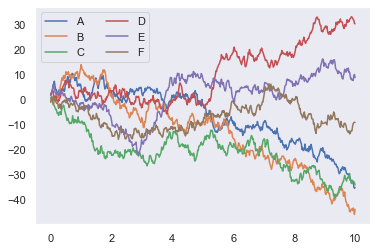

```python
%matplotlib inline

import matplotlib.pyplot as plt
import numpy as np
import pandas as pd

rng = np.random.RandomState(0)
x = np.linspace(0, 10, 500)
y = np.cumsum(rng.randn(500, 6), 0)

# Plot the data with Matplotlib defaults
plt.plot(x, y)
plt.legend('ABCDEF', ncol=2, loc='upper left')
```

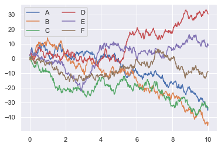

```python
%matplotlib inline

import matplotlib.pyplot as plt
import numpy as np
import pandas as pd
import seaborn as sns

rng = np.random.RandomState(0)
x = np.linspace(0, 10, 500)
y = np.cumsum(rng.randn(500, 6), 0)

#seaborn style
#要使用 seaborn 初始設定就呼叫 set()
sns.set()
#sns.set(style="white") # darkgrid, whitegrid, dark, white, ticks

# same plotting code as above
#seaborn 是建立在 matplotlib 之上, 因此 matplotlib 也可以直接拿來跟 seaborn 產生的圖互動
plt.plot(x,y)
plt.legend('ABCDEF', ncol=2, loc='upper left')
```

# relplot

This is a figure-level function for visualizing statistical relationships using two common approaches: scatter plots and line plots. relplot() combines a FacetGrid with one of two axes-level functions:

- `scatterplot()＝relplot()` (with kind="scatter"; the default)
- `lineplot()＝relplot()` (with kind="line")

```
    A   B  C
0   2  10  4
1   6   6  7
2   5   2  3
3  10   1  2
4   5   2  8
```

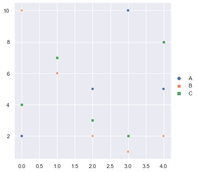

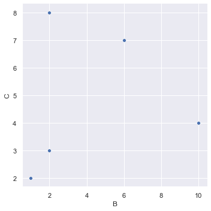

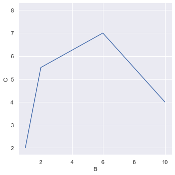

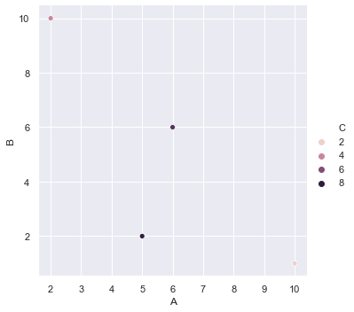

```python
%matplotlib inline

import matplotlib.pyplot as plt
import numpy as np
import pandas as pd
import seaborn as sns

data = np.random.randint(0, 11, (5, 3))
df = pd.DataFrame(data, columns=list('ABC'))

print(df)

sns.relplot(data=df)  #Input data structure
sns.relplot(x="B", y="C",data=df)
sns.relplot(x="B", y="C",data=df, kind="line")
sns.relplot(x="A", y="B",hue="C", data=df)
#hue：可對x軸的數據進行細分，條件為'hue'的參數值，此例x軸是'A'，按'C'再進行細分以不同顏色表示
```

```python
df = pd.DataFrame({
    'x': np.random.randn(100),
    'y': np.random.randn(100)})
df.head(5)
```

|  | x | y |
| --- | --- | --- |
| 0 | 1.487510 | -0.275910 |
| 1 | 0.574916 | -0.067964 |
| 2 | -1.922173 | -0.518173 |
| 3 | 0.163571 | 0.351688 |
| 4 | 0.724757 | -2.837923 |

```
  NAME  General_Physics  Classical_Mechanics  Calculus  Optics  Statistics  \
0   S1               99                   64        21      70          67
1   S2               41                   82        31      68          58
2   S3               91                   78        72      85          36
3   S4               52                   67        33      65          46
4   S5               67                   79        77      18          93
5   S6               71                   55        56      18          90
6   S7               91                   37        21      82          12
7   S8               70                   70        51      61          69
8   S9               99                   91        61      39          57
9  S10               70                   79        47      34          60

    Address
0    Taipei
1  Taichung
2    Tainan
3   Hsinchu
4    Tainan
5    Taipei
6    Taipei
7   Hsinchu
8    Taipei
9  Taichung
```

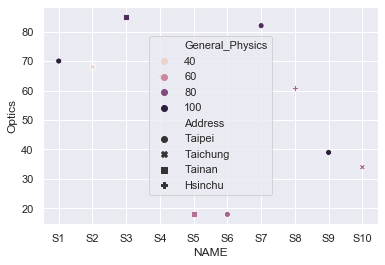

```python
%matplotlib inline

import matplotlib.pyplot as plt
import numpy as np
import pandas as pd
import seaborn as sns

data_csv = pd.read_csv('filename_csv.csv')
data_csv["Address"] = pd.Series(
                ["Taipei", "Taichung", "Tainan", "Hsinchu", "Tainan", "Taipei", "Taipei", "Hsinchu", "Taipei", "Taichung"]
                )

print(data_csv)
sns.scatterplot(x="NAME" ,y="Optics", hue="General_Physics", style="Address", data=data_csv)
```

## Barplot 直方圖

```
  NAME  General_Physics  Classical_Mechanics  Calculus  Optics  Statistics
0   S1               99                   64        21      70          67
1   S2               41                   82        31      68          58
2   S3               91                   78        72      85          36
3   S4               52                   67        33      65          46
4   S5               67                   79        77      18          93
5   S6               71                   55        56      18          90
6   S7               91                   37        21      82          12
7   S8               70                   70        51      61          69
8   S9               99                   91        61      39          57
9  S10               70                   79        47      34          60
       General_Physics  Classical_Mechanics   Calculus     Optics  Statistics
count        10.000000            10.000000  10.000000  10.000000   10.000000
mean         75.100000            70.200000  47.000000  54.000000   58.800000
std          19.660734            15.526322  20.061018  24.908722   24.022212
min          41.000000            37.000000  21.000000  18.000000   12.000000
25%          67.750000            64.750000  31.500000  35.250000   48.750000
50%          70.500000            74.000000  49.000000  63.000000   59.000000
75%          91.000000            79.000000  59.750000  69.500000   68.500000
max          99.000000            91.000000  77.000000  85.000000   93.000000
   General_Physics  Classical_Mechanics  Calculus  Optics  Statistics
0               99                   64        21      70          67
1               41                   82        31      68          58
2               91                   78        72      85          36
3               52                   67        33      65          46
4               67                   79        77      18          93
5               71                   55        56      18          90
6               91                   37        21      82          12
7               70                   70        51      61          69
8               99                   91        61      39          57
9               70                   79        47      34          60
```

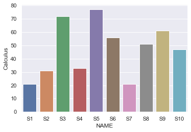

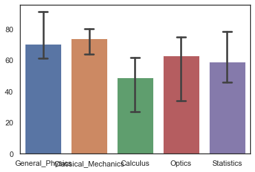

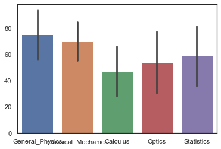

```python
%matplotlib inline

import matplotlib.pyplot as plt
import numpy as np
import pandas as pd
import seaborn as sns

fig = plt.figure()
axe = fig.add_subplot()

df = pd.read_csv('filename_csv.csv')

print(df)
print(df.describe())

sns.set(style="white")
sns.barplot(x="NAME", y="Calculus",data=df)


df2 = df.drop(['NAME'], axis=1)
print(df2)
fig = plt.figure()
sns.barplot(data=df2,  estimator=np.median, capsize=.2) #Use median（中位數） as the estimate of central tendency，預設為平均值
#以列中的數值進行歸類後，按照estimator參數的方法計算相應的值，計算出來的值就作為條形圖所顯示的值
#capsize=誤差槓的大小


fig = plt.figure()
#sns.barplot(data=df2, ci=95) #Show the standard error of the mean with the error bars
sns.barplot(data=df2, ci="sd")#Show standard deviation of observations instead of a confidence interval
```

```
   age  color  gender  height smoker  weight
0   55  green    Male     154     No      87
1   35  green  Female     151     No      66
2   35  green  Female     168    Yes      40
3   81   blue    Male     180     No      41
4   45   blue    Male     173    Yes      64
```

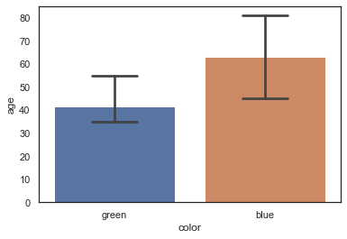

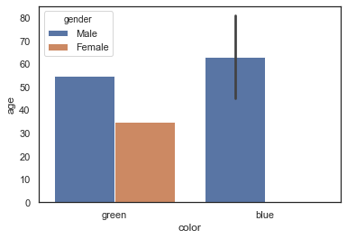

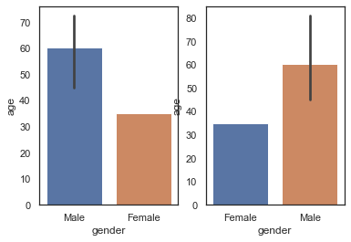

```python
%matplotlib inline

import matplotlib.pyplot as plt
import numpy as np
import pandas as pd
import seaborn as sns


df = pd.DataFrame({
    "age" : [55, 35, 35, 81, 45],
    "color" : ["green", "green", "green", "blue", "blue"],
    "gender" : ["Male", "Female","Female","Male","Male"],
    "height" : [154, 151, 168, 180, 173],
    "smoker" : ["No", "No","Yes","No","Yes"],
    "weight" : [87, 66, 40, 41, 64],
                })

print(df)
fig = plt.figure()
sns.barplot(x="color", y="age", data=df, capsize=.3)

fig = plt.figure()
sns.barplot(x="color", y="age", data=df, hue="gender")


fig,axes=plt.subplots(1,2)
sns.barplot(x="gender", y="age", data=df, ax=axes[0])
sns.barplot(x="gender", y="age", data=df, ax=axes[1], order=["Female","Male"]) #change order
```

### Displot 分布密度圖

同時呈現直方圖和密度圖，可以更好地去評估分布的組成。

預設會擬合出密度曲線Kernel density estimation (KDE)，可以看出分布的變化規律。

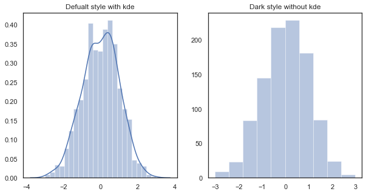

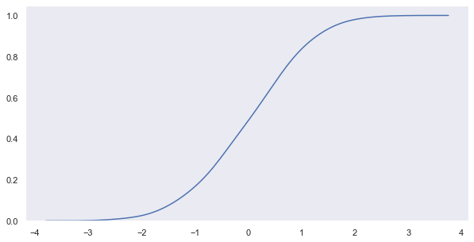

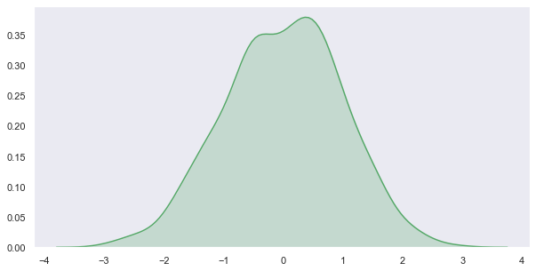

```python
%matplotlib inline

import matplotlib.pyplot as plt
import numpy as np
import pandas as pd
import seaborn as sns

data = np.random.randn(1000) #隨機生成1000個符合常態分布的數字

plt.figure(figsize=(10, 5))

plt.subplot(1, 2, 1)
plt.title('Defualt style with kde')
sns.distplot(data, kde=True)

plt.subplot(1, 2, 2)
sns.set_style('dark')
plt.title('Dark style without kde')
sns.distplot(data, bins=10, kde=False)
#sns.distplot(data, bins=5, kde=False)

plt.figure(figsize=(10, 5))
sns.kdeplot(data, cumulative=True) #累計分佈

plt.figure(figsize=(10, 5))
sns.kdeplot(data, shade=True, color="g") #kde曲線下面的區域中進行陰影處理，color控制曲線及陰影的顏色
```

可同時繪製出散佈圖（scatter）和回歸（Regression），可以很快速地評估該資料是否有某種趨勢。

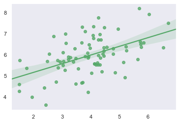

```python
%matplotlib inline

import matplotlib.pyplot as plt
import numpy as np
import pandas as pd
import seaborn as sns

mean, cov = [4, 6], [(1.5, .7), (.7, 1)]
x, y = np.random.multivariate_normal(mean, cov, 80).T

ax = sns.regplot(x=x, y=y, color="g")
```

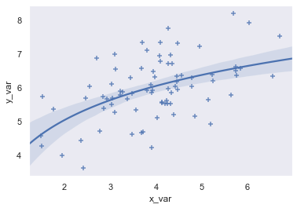

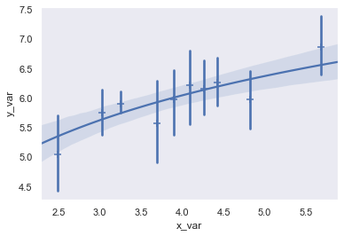

```python
%matplotlib inline

import matplotlib.pyplot as plt
import numpy as np
import pandas as pd
import seaborn as sns

plt.figure()
x, y = pd.Series(x, name="x_var"), pd.Series(y, name="y_var")
ax = sns.regplot(x=x, y=y, marker="+", logx=True)

plt.figure()
ax = sns.regplot(x=x, y=y, marker="+", x_bins=10 ,x_estimator=np.mean, logx=True)
```

## kdeplot & jointplot

```
  NAME  General_Physics  Classical_Mechanics  Calculus  Optics  Statistics
0   S1               99                   64        21      70          67
1   S2               41                   82        31      68          58
2   S3               91                   78        72      85          36
3   S4               52                   67        33      65          46
4   S5               67                   79        77      18          93
5   S6               71                   55        56      18          90
6   S7               91                   37        21      82          12
7   S8               70                   70        51      61          69
8   S9               99                   91        61      39          57
9  S10               70                   79        47      34          60
       General_Physics  Classical_Mechanics   Calculus     Optics  Statistics
count        10.000000            10.000000  10.000000  10.000000   10.000000
mean         75.100000            70.200000  47.000000  54.000000   58.800000
std          19.660734            15.526322  20.061018  24.908722   24.022212
min          41.000000            37.000000  21.000000  18.000000   12.000000
25%          67.750000            64.750000  31.500000  35.250000   48.750000
50%          70.500000            74.000000  49.000000  63.000000   59.000000
75%          91.000000            79.000000  59.750000  69.500000   68.500000
max          99.000000            91.000000  77.000000  85.000000   93.000000
```

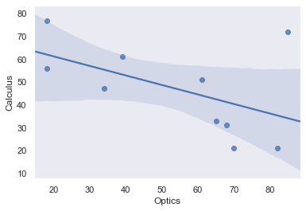

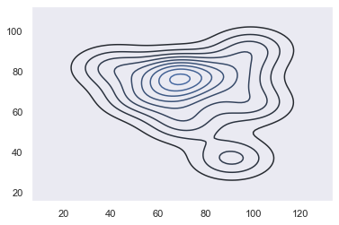

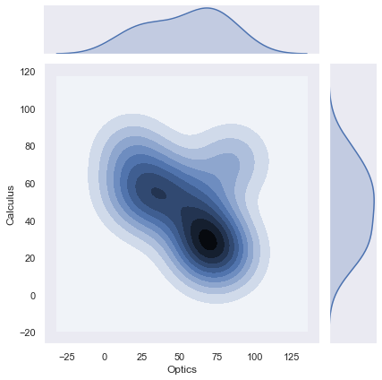

```python
%matplotlib inline

import matplotlib.pyplot as plt
import numpy as np
import pandas as pd
import seaborn as sns

fig = plt.figure()
axe = fig.add_subplot()

df = pd.read_csv('filename_csv.csv')

print(df)
print(df.describe())

sns.regplot(x="Optics", y="Calculus",data=df)

df2 = df.drop(['NAME'], axis=1)
fig = plt.figure()
sns.kdeplot(data=df2)

fig = plt.figure()
sns.jointplot("Optics", "Calculus", df2, kind='kde')#kind{ “scatter” | “kde” | “hist” | “hex” | “reg” | “resid” }
```

```
   age  color  gender  height smoker  weight
0   55  green    Male     154     No      87
1   35  green  Female     151     No      66
2   35  green  Female     168    Yes      40
3   81   blue    Male     180     No      41
4   45   blue    Male     173    Yes      64
```

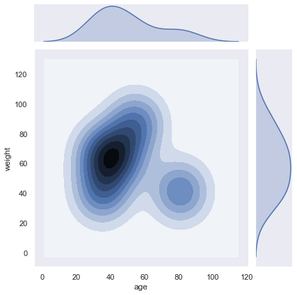

```python
%matplotlib inline

import matplotlib.pyplot as plt
import numpy as np
import pandas as pd
import seaborn as sns


df = pd.DataFrame({
    "age" : [55, 35, 35, 81, 45],
    "color" : ["green", "green", "green", "blue", "blue"],
    "gender" : ["Male", "Female","Female","Male","Male"],
    "height" : [154, 151, 168, 180, 173],
    "smoker" : ["No", "No","Yes","No","Yes"],
    "weight" : [87, 66, 40, 41, 64],
                })

print(df)
fig = plt.figure()

sns.jointplot("age", "weight", df, kind='kde')
```

### Pairplot 散佈圖矩陣

在探索資料時，若能看到不同變數間的散佈圖非常有幫助，但如果一個一個繪製不僅容易忘記，也很難直接看到不同變數間的關係。這時 pairplot 就派上用場了

```
  NAME  General_Physics  Classical_Mechanics  Calculus  Optics  Statistics  \
0   S1               99                   64        21      70          67
1   S2               41                   82        31      68          58
2   S3               91                   78        72      85          36
3   S4               52                   67        33      65          46
4   S5               67                   79        77      18          93
5   S6               71                   55        56      18          90
6   S7               91                   37        21      82          12
7   S8               70                   70        51      61          69
8   S9               99                   91        61      39          57
9  S10               70                   79        47      34          60

    Address
0    Taipei
1  Taichung
2    Tainan
3   Hsinchu
4    Tainan
5    Taipei
6    Taipei
7   Hsinchu
8    Taipei
9  Taichung
       General_Physics  Classical_Mechanics   Calculus     Optics  Statistics
count        10.000000            10.000000  10.000000  10.000000   10.000000
mean         75.100000            70.200000  47.000000  54.000000   58.800000
std          19.660734            15.526322  20.061018  24.908722   24.022212
min          41.000000            37.000000  21.000000  18.000000   12.000000
25%          67.750000            64.750000  31.500000  35.250000   48.750000
50%          70.500000            74.000000  49.000000  63.000000   59.000000
75%          91.000000            79.000000  59.750000  69.500000   68.500000
max          99.000000            91.000000  77.000000  85.000000   93.000000
```

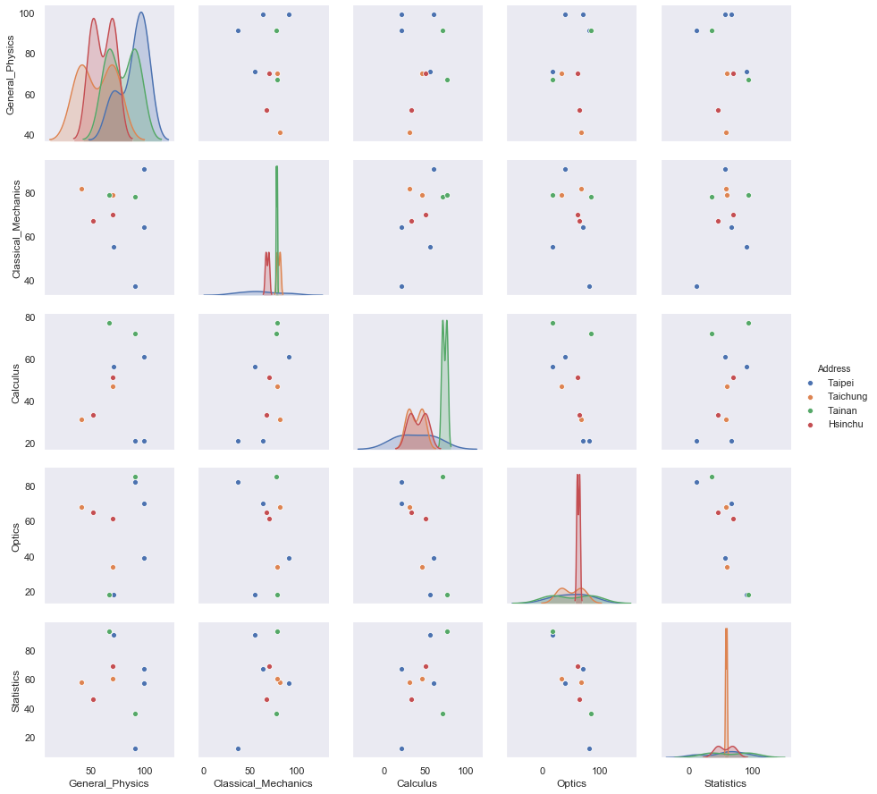

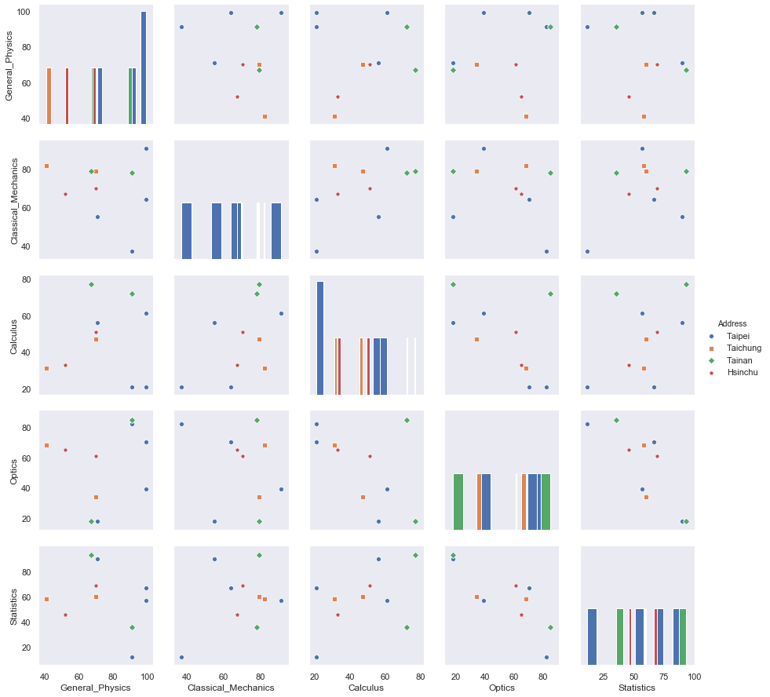

```python
%matplotlib inline

import matplotlib.pyplot as plt
import numpy as np
import pandas as pd
import seaborn as sns

df = pd.read_csv('filename_csv.csv')
df["Address"] = pd.Series(
                ["Taipei", "Taichung", "Tainan", "Hsinchu", "Tainan", "Taipei", "Taipei", "Hsinchu", "Taipei", "Taichung"]
                )
print(df)
print(df.describe())

fig = plt.figure()
sns.pairplot(df, hue="Address", diag_kind="kde")
#sns.pairplot(df, hue="Address", diag_kind="hist")

fig = plt.figure()
sns.pairplot(df, hue="Address", markers=["o", "s", "D", "p"], diag_kind="hist")
```

# Bokeh

Bokeh可以讓圖表呈現動態的樣子，像是可以用滑鼠拖曳或縮放。在瀏覽器開啟

#### 參考資料

- https://docs.bokeh.org/en/latest/index.html
- https://ithelp.ithome.com.tw/articles/10196690
- https://mybinder.org/v2/gh/bokeh/bokeh-notebooks/master?filepath=tutorial%2F00%20-%20Introduction%20and%20Setup.ipynb
- 引入套件

`from bokeh.plotting import figure, show`

## scatter plot

```python
from bokeh.plotting import figure, show

p = figure(plot_width=500, plot_height=500)

x = [1,2,3,4,5,6,7,8,9,10,11]
y = [6,3,7,2,4,6,1,2,3,5,6]

p.circle(x, y, size=20, color="gray", alpha=0.6)
show(p)
```

## line plot

```python
from bokeh.plotting import figure, show

p = figure(plot_width=500, plot_height=500)

x = [1,2,3,4,5,6,7,8,9,10,11]
y = [6,3,7,2,4,6,1,2,3,5,6]

p.circle(x, y, size=20, color="gray", alpha=0.6)
show(p)

p.line(x, y, line_width=3)
show(p)
```

## Multiple Lines

```python
from bokeh.plotting import figure, show

p = figure(plot_width=500, plot_height=500)

x1 = [1, 2, 3]
x2 = [2, 3, 4, 5, 6]
y1 = [3, 2, 5]
y2 = [3, 2, 4, 1, 3]

p.multi_line([x1,x2] , [y1, y2],
             color=["firebrick", "navy"], alpha=[0.8, 0.3], line_width=5)
show(p)
```

## bars

```python
p = figure(plot_width=500, plot_height=500)
p.vbar(x=[1, 2, 3, 4], width=0.5, bottom=0,
       top=[1.2, 2.5, 3.7, 2.9], color="black",alpha=0.4)
show(p)
```

## Multiple Patches

```python
p = figure(plot_width=500, plot_height=500)
x1 = [1, 4, 5, 2]
x2 = [3, 4, 5, 6]
x3 = [1,3,2]
y1 = [2, 3, 5, 6]
y2 = [4, 7, 7, 5]
y3 = [7,8,5.5]
p.patches([x1,x2,x3 ], [y1,y2,y3],
          color=["black", "navy","firebrick"], alpha=[0.2, 0.2,0.3], line_width=2)

show(p)
```

# Plotly

- open-source 科學圖形函式庫(library)，主要用來畫圖，幫助統計分析與報表呈現，它還能更進一步做到視覺化互動報表，相比 Matplotlib 與 Seaborn，它將資料視覺化提升到新層次。
- Plotly 內建完整的互動能力和編輯工具，支援線上和離線模式，提供穩定的 API 使其與現有應用整合，既能在瀏覽器展示圖表，也能存入本地。
- Plotly是使用Python和Django框架構建的，前端使用JavaScript和可視化庫D3.js，HTML和CSS。使用Plotly可以創建出許多精美的互動式圖表。

#### 參考資料

- https://plotly.com/python/
- https://igoamazing.com/python-plotly/
- https://medium.com/@auwit0205/dash-by-plotly-%E7%B0%A1%E5%96%AE%E4%BB%8B%E7%B4%B9-ba81f5ef4e29
- https://ithelp.ithome.com.tw/articles/10214872

## 安裝

`conda install -c plotly plotly`

### Jupyter Notebook Support

**notebook** and **ipywidgets** packages are needed.

```python
import plotly.graph_objects as go

fig = go.Figure(data=go.Bar(y=[2, 3, 1]))
fig.write_html('first_figure.html', auto_open=True)
#在瀏覽器開啟
```

```python
import plotly.graph_objects as go

fig = go.Figure(data=go.Bar(y=[2, 3, 1]))
fig.show()
```

[interactive chart not shown]

## Slider Control

https://plotly.com/python/sliders/

```python
import plotly.graph_objects as go
import numpy as np

# Create figure
fig = go.Figure()

# Add traces, one for each slider step
for step in np.arange(0, 5, 0.1):
    fig.add_trace(
        go.Scatter(
            visible=False,
            line=dict(color="#00CED1", width=6),
            name="𝜈 = " + str(step),
            x=np.arange(0, 10, 0.01),
            y=np.sin(step * np.arange(0, 10, 0.01))))

# Make 10th trace visible
fig.data[10].visible = True

# Create and add slider
steps = []
for i in range(len(fig.data)):
    step = dict(
        method="update",
        args=[{"visible": [False] * len(fig.data)},
              {"title": "Slider switched to step: " + str(i)}],  # layout attribute
    )
    step["args"][0]["visible"][i] = True  # Toggle i'th trace to "visible"
    steps.append(step)

sliders = [dict(
    active=10,
    currentvalue={"prefix": "Frequency: "},
    pad={"t": 50},
    steps=steps
)]

fig.update_layout(
    sliders=sliders
)

fig.show()
```

[interactive chart not shown]

## Bubble map with Plotly Express

```python
import plotly.express as px
df = px.data.gapminder().query("year==2007")
fig = px.scatter_geo(df, locations="iso_alpha", color="continent",
                     hover_name="country", size="pop",
                     projection="natural earth")
fig.show()
```

[interactive chart not shown]

## Animation

https://plotly.com/python/animations/

```python
import plotly.express as px
df = px.data.gapminder()
px.scatter(df, x="gdpPercap", y="lifeExp", animation_frame="year", animation_group="country",
           size="pop", color="continent", hover_name="country",
           log_x=True, size_max=55, range_x=[100,100000], range_y=[25,90])
```

[interactive chart not shown]

## Bubble Map with animation

```python
import plotly.express as px
df = px.data.gapminder()
fig = px.scatter_geo(df, locations="iso_alpha", color="continent",
                     hover_name="country", size="pop",
                     animation_frame="year",
                     projection="natural earth")
fig.show()
```

[interactive chart not shown]

## Visualization of MRI volume slices

https://plotly.com/python/visualizing-mri-volume-slices/

```python
# Import data
import time
import numpy as np

from skimage import io

vol = io.imread("https://s3.amazonaws.com/assets.datacamp.com/blog_assets/attention-mri.tif")
volume = vol.T
r, c = volume[0].shape

# Define frames
import plotly.graph_objects as go
nb_frames = 68

fig = go.Figure(frames=[go.Frame(data=go.Surface(
    z=(6.7 - k * 0.1) * np.ones((r, c)),
    surfacecolor=np.flipud(volume[67 - k]),
    cmin=0, cmax=200
    ),
    name=str(k) # you need to name the frame for the animation to behave properly
    )
    for k in range(nb_frames)])

# Add data to be displayed before animation starts
fig.add_trace(go.Surface(
    z=6.7 * np.ones((r, c)),
    surfacecolor=np.flipud(volume[67]),
    colorscale='Gray',
    cmin=0, cmax=200,
    colorbar=dict(thickness=20, ticklen=4)
    ))


def frame_args(duration):
    return {
            "frame": {"duration": duration},
            "mode": "immediate",
            "fromcurrent": True,
            "transition": {"duration": duration, "easing": "linear"},
        }

sliders = [
            {
                "pad": {"b": 10, "t": 60},
                "len": 0.9,
                "x": 0.1,
                "y": 0,
                "steps": [
                    {
                        "args": [[f.name], frame_args(0)],
                        "label": str(k),
                        "method": "animate",
                    }
                    for k, f in enumerate(fig.frames)
                ],
            }
        ]

# Layout
fig.update_layout(
         title='Slices in volumetric data',
         width=600,
         height=600,
         scene=dict(
                    zaxis=dict(range=[-0.1, 6.8], autorange=False),
                    aspectratio=dict(x=1, y=1, z=1),
                    ),
         updatemenus = [
            {
                "buttons": [
                    {
                        "args": [None, frame_args(50)],
                        "label": "&#9654;", # play symbol
                        "method": "animate",
                    },
                    {
                        "args": [[None], frame_args(0)],
                        "label": "&#9724;", # pause symbol
                        "method": "animate",
                    },
                ],
                "direction": "left",
                "pad": {"r": 10, "t": 70},
                "type": "buttons",
                "x": 0.1,
                "y": 0,
            }
         ],
         sliders=sliders
)

fig.show()
```